# CML SNV mixed models

# Aim

This analysis is to explore the best SNV burden mixed model to fit the CML colony data

## Setup

### Libraries

```r
knitr::opts_chunk$set(collapse = TRUE)

library(tidyverse)
library(magrittr)

library(ggbeeswarm)
library(ggtext)
library(ggeffects)
library(ggnewscale)
library(ggh4x)
library(scales)
library(patchwork)

library(lme4)
library(optimx)
library(dfoptim)
library(lmeresampler)

library(sjPlot)
library(performance)
library(parameters)

import::from(.from = "dplyr", count, select, rename, slice)
```

### Functions

```r
# Add totals to df
addTotal <-
  function(df) {
    df %>% mutate(across(where(is.logical), as.character)) %>%
      bind_rows(summarise(.,
                          across(where(is.numeric), sum,  na.rm = T),
                          across(where(is.character), ~ "Total")))
  }

# Lmer optimiser QC

# allfit summary
all_fit.summary <- function(all_fit) {
  broom.mixed::glance(all_fit) %>%  select(optimizer, AIC, BIC, NLL_rel)  %>%  arrange(NLL_rel)

}


# allfit compare estimated ranked by fit metrics
all_fit.compare <- function(all_fit) {
  Reduce(left_join, list(
    broom.mixed::glance(all_fit),
    Reduce(bind_rows, list(broom.mixed::tidy(all_fit) %>% filter(effect == "fixed"),
    lapply(all_fit, function(x){ x@optinfo$conv$opt}) %>% unlist() %>% enframe(name = "optimizer", value = "estimate") %>% mutate(term = "lme4.optimizer_code"),
    lapply(all_fit, function(x){ as.numeric(isSingular(x))}) %>% unlist() %>% enframe(name = "optimizer", value = "estimate") %>% mutate(term = "isSingular"),
    lapply(all_fit, function(x){ as.numeric(check_convergence(x))}) %>% unlist() %>% enframe(name = "optimizer", value = "estimate") %>% mutate(term = "Converged")
  ))))  %>%
  ggplot(aes(reorder(optimizer, -NLL_rel), estimate, colour = optimizer)) +
  geom_point() +
  facet_grid(0 ~ term, scale = "free_x") +
  coord_flip() + guides(colour = "none") +
  theme(axis.text.x = element_text(angle = 30, hjust = 1, vjust = 1))

}

#  Model check
model.check <- function(model) {
  n <- rlang::expr_name(rlang::enexpr(model))
  res <- enframe(c(
    "Formula" = unlist(str_split(as.character(model@call), pattern = "\\="))[2],
    "Observations" = nrow(model@frame),
    "REML" = isREML(model),
    "Optimizer" = model@optinfo$optimizer,
    "Singular" = isSingular(model),
    "Converged" = check_convergence(model)
  )) %>%  tab_df(title = paste0("Model ", n),
                 col.header = c("Test", "Value"))
  return(res)
}

# get model formula
get_formula <- function(model) {
  str_sub(unlist(str_split(as.character(model@call), pattern = "\\="))[2])

}
```

## Data

```r
per_sample_statistics.n834.df <-
  read_csv("../data/per_sample_statistics.n834.csv")
driver.palette <- c(`Wild-type` = "#0072B5FF", Other ="#E18727FF",  `*BCR::ABL1*`="#BC3C29FF")
driver.palette1 <- c(WT = "#0072B5FF", Other ="#E18727FF",  BCR_ABL="#BC3C29FF")
driver.palette2 <- c(Wt = "#0072B5FF", Mt="#BC3C29FF")
driver.palette2b <- c(Absence = "#717D6E", Presence="#BC3C29FF")
```

### Setup analysis variables

```r
# BCR::ABL1-mutated vs non mutated
per_sample_statistics.n834.df %<>%
  mutate(BCR_ABL1 = ifelse(grepl("BCR::ABL1", driver3, perl = T), "Mt", "Wt"))

#  set Wt as ref
per_sample_statistics.n834.df %<>%  mutate(BCR_ABL1 = factor(BCR_ABL1, levels = c("Wt", "Mt")))


# BCR::ABL1-mutated vs Other driver vs wildtype
per_sample_statistics.n834.df %<>% mutate(driver2 = ifelse(driver3 == "WT", "WT", ifelse(
  grepl("BCR::ABL1", driver3, perl = T),
  "BCR_ABL",
  "Other"
)))

per_sample_statistics.n834.df %<>% mutate(driver2 = factor(driver2, levels = c("WT", "Other", "BCR_ABL")))

# Set batch variable as character
per_sample_statistics.n834.df %<>% mutate(library.cluster = as.character(library.cluster))
```

In total 834 samples passed QC across 9 patients. Age (age_at_sample_exact) was defined as the count of completed years from birth at sampling and sample mutant status (BCR_ABL1) was defined as *BCR::ABL1* positive (Mt; n=365) or negative (Wt; n=469).

```r
per_sample_statistics.n834.df %>%  count(Patient, BCR_ABL1) %>% pivot_wider(names_from = BCR_ABL1, values_from = n) %>%  addTotal() %>%  tab_df()
```

| Patient | Wt | Mt |
| --- | --- | --- |
| PD51632 | 24 | 59 |
| PD51633 | 77 | 4 |
| PD51634 | 48 | 75 |
| PD51635 | 85 | 32 |
| PD56961 | 105 | 58 |
| PD57332 | NA | 35 |
| PD57333 | 75 | NA |
| PD57334 | 44 | 11 |
| PD57335 | 11 | 91 |
| Total | 469 | 365 |

### Add labels

```r
attr(per_sample_statistics.n834.df$Length, "label") <- "Mean telomere length (bp)"
attr(per_sample_statistics.n834.df$nsub_adj, "label") <- "SNV burden (depth adjusted)"
attr(per_sample_statistics.n834.df$age_at_sample_exact, "label") <- "Age (years)"
attr(per_sample_statistics.n834.df$BCR_ABL1, "label") <- "BCR::ABL1 status"
attr(per_sample_statistics.n834.df$driver2, "label") <- "Driver status"
```

## Use of mixed models

# SNV model analysis

To model the effect of *BCR::ABL1* fusion status on SNV burden (nsub_adj), we will build the model (accounting for batch) in a stepwise fashion:

1. Confirm a *BCR::ABL* fusion status effect as a fixed effect only
2. Test the addition of explanatory variables to the random effect configuration

## 0. Remove PD57332 samples due to lack of wild-type

```r
per_sample_statistics.n799.df <- per_sample_statistics.n834.df %>%  filter(Patient != "PD57332")
plot3a.per_sample_statistics.n834.df <- per_sample_statistics.n834.df
rm(per_sample_statistics.n834.df)
```

As PD57332 didn’t have any wild-type colonies our estimations of SNV mutation burden (nsub_adj) were expected to be biased, therefore we removed this patient from SNV burden analysis, leaving 799 samples passed QC across 8 patients. Age (age_at_sample_exact) was defined as the count of completed years from birth at sampling and sample mutant status (BCR_ABL1) was defined as *BCR::ABL1* positive (Mt; n=330) or negative (Wt; n=469).

```r
per_sample_statistics.n799.df %>%  count(Patient, BCR_ABL1) %>% pivot_wider(names_from = BCR_ABL1, values_from = n) %>%  addTotal() %>%  tab_df()
```

| Patient | Wt | Mt |
| --- | --- | --- |
| PD51632 | 24 | 59 |
| PD51633 | 77 | 4 |
| PD51634 | 48 | 75 |
| PD51635 | 85 | 32 |
| PD56961 | 105 | 58 |
| PD57333 | 75 | NA |
| PD57334 | 44 | 11 |
| PD57335 | 11 | 91 |
| Total | 469 | 330 |

## 1. Is there a driver (2-level, BCR::ABL1 or non-BCR::ABL1) effect on SNV nsub_adj?

Using the subset dataset (n=799), we compare the inclusion of *BCR::ABL1* fusion status as a fixed effect to a null model “nsub_adj ~ age_at_sample_exact + (1 | Patient)”.

#### Null model

```r
SNV.lmer_0 <-
  lmer(
    nsub_adj ~  age_at_sample_exact + (1 | Patient),
    data = per_sample_statistics.n799.df , REML = F
  )

model.check(SNV.lmer_0)
```

Model SNV.lmer_0

| Test | Value |
| --- | --- |
| Formula | nsub_adj ~ age_at_sample_exact + (1 \| Patient) |
| Observations | 799 |
| REML | FALSE |
| Optimizer | nloptwrap |
| Singular | FALSE |
| Converged | TRUE |

#### Model 1 - driver as fixed effect

```r
SNV.lmer2_1 <-
  lmer(
    nsub_adj ~  age_at_sample_exact + BCR_ABL1 +  (1 | Patient),
    data = per_sample_statistics.n799.df, REML = F
  )

model.check(SNV.lmer2_1)
```

Model SNV.lmer2_1

| Test | Value |
| --- | --- |
| Formula | nsub_adj ~ age_at_sample_exact + BCR_ABL1 + (1 \| Patient) |
| Observations | 799 |
| REML | FALSE |
| Optimizer | nloptwrap |
| Singular | FALSE |
| Converged | TRUE |

### Compare null to driver as fixed effect

Adding *BCR::ABL* fusion status as a fixed effect improves the model fit to the data (SNV.lmer2_1; BIC=8762.57) over the null model (SNV.lmer_0; BIC=8907.52), confirming a *BCR::ABL* fusion status effect.

```r
tab_model(
  SNV.lmer_0,
  SNV.lmer2_1,
  show.se = T,
  show.stat = T,
  show.ci = F,
  show.p = F,
  p.style = "scientific",
  dv.labels = c("Baseline (SNV.lmer_0)", "Driver as fixed effect (SNV.lmer2_1)")
)
```

|  | Baseline (SNV.lmer_0) |  |  | Driver as fixed effect (SNV.lmer2_1) |  |  |
| --- | --- | --- | --- | --- | --- | --- |
| Predictors | Estimates | std. Error | Statistic | Estimates | std. Error | Statistic |
| (Intercept) | 592.14 | 71.71 | 8.26 | 87.96 | 54.83 | 1.60 |
| Age(years) | 7.68 | 0.65 | 11.83 | 16.89 | 0.87 | 19.51 |
| BCR::ABL 1 status: Mt |  |  |  | 97.65 | 7.28 | 13.41 |
| Random Effects |  |  |  |  |  |  |
| σ<sup>2</sup> | 3676.00 |  |  | 3081.62 |  |  |
| τ<sub>00</sub> | 32459.93 <sub>Patient</sub> |  |  | 7108.98 <sub>Patient</sub> |  |  |
| ICC | 0.90 |  |  | 0.70 |  |  |
| N | 8 <sub>Patient</sub> |  |  | 8 <sub>Patient</sub> |  |  |
| Observations | 799 |  |  | 799 |  |  |
| Marginal R<sup>2</sup> / Conditional R<sup>2</sup> | 0.189 / 0.918 |  |  | 0.789 / 0.936 |  |  |

#### ANOVA

```r
broom::tidy(anova(SNV.lmer_0, SNV.lmer2_1)) %>%
mutate(p.value = format.pval(p.value, digits = 3, eps = 1e-50)) %>% tab_df()
```

| term | npar | AIC | BIC | logLik | deviance | statistic | df | p.value |
| --- | --- | --- | --- | --- | --- | --- | --- | --- |
| SNV.lmer_0 | 4 | 8888.79 | 8907.52 | -4440.39 | 8880.79 | NA | NA | NA |
| SNV.lmer2_1 | 5 | 8739.15 | 8762.57 | -4364.58 | 8729.15 | 151.63 | 1 | 7.63e-35 |

## 2. Random effect configuration

- Model 2 - Age at sampling
- Model 3 - *BCR::ABL* fusion status

#### Model 2

```r
SNV.lmer2_2 <-
  lmer(
    nsub_adj ~  age_at_sample_exact + BCR_ABL1 + (1 + age_at_sample_exact | Patient),
    data = per_sample_statistics.n799.df,
    REML = F
  )
model.check(SNV.lmer2_2)
```

Model SNV.lmer2_2

| Test | Value |
| --- | --- |
| Formula | nsub_adj ~ age_at_sample_exact + BCR_ABL1 + (1 + age_at_sample_exact \| Patient) |
| Observations | 799 |
| REML | FALSE |
| Optimizer | nloptwrap |
| Singular | FALSE |
| Converged | FALSE |

##### Check optimisers

```r
SNV.lmer2_2.af <- allFit(SNV.lmer2_2)
## bobyqa : [OK]
## Nelder_Mead : [OK]
## nlminbwrap : [OK]
## nmkbw :
## Warning in checkConv(attr(opt, "derivs"), opt$par, ctrl = control$checkConv, : Model failed to converge with max|grad| = 0.00472266 (tol = 0.002, component 1)
## [OK]
## optimx.L-BFGS-B :
## Warning in checkConv(attr(opt, "derivs"), opt$par, ctrl = control$checkConv, : Model failed to converge with max|grad| = 0.0469593 (tol = 0.002, component 1)
## [OK]
## nloptwrap.NLOPT_LN_NELDERMEAD :
## Warning in checkConv(attr(opt, "derivs"), opt$par, ctrl = control$checkConv, : Model failed to converge with max|grad| = 0.00208286 (tol = 0.002, component 1)
## [OK]
## nloptwrap.NLOPT_LN_BOBYQA :
## Warning in checkConv(attr(opt, "derivs"), opt$par, ctrl = control$checkConv, : Model failed to converge with max|grad| = 0.0280556 (tol = 0.002, component 1)
## [OK]

all_fit.summary(SNV.lmer2_2.af)
```

| optimizer | AIC | BIC | NLL_rel |
| --- | --- | --- | --- |
| Nelder_Mead | 8690.209 | 8722.993 | 0.000000e+00 |
| nlminbwrap | 8690.209 | 8722.993 | 9.949872e-10 |
| bobyqa | 8690.209 | 8722.993 | 9.044015e-09 |
| nloptwrap.NLOPT_LN_NELDERMEAD | 8690.209 | 8722.993 | 3.417608e-08 |
| nmkbw | 8690.209 | 8722.993 | 1.870667e-07 |
| optimx.L-BFGS-B | 8690.209 | 8722.993 | 1.398382e-04 |
| nloptwrap.NLOPT_LN_BOBYQA | 8690.215 | 8722.999 | 3.125198e-03 |

##### Plot optimiser outputs

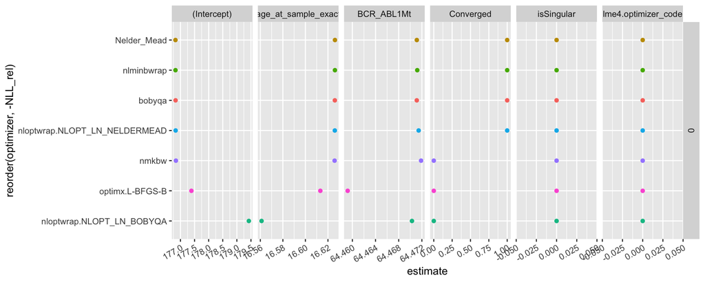

```r
all_fit.compare(SNV.lmer2_2.af)
## Joining with `by = join_by(optimizer)`
```

##### Select best optimiser

```r
SNV.lmer2_2 <- SNV.lmer2_2.af$Nelder_Mead

model.check(SNV.lmer2_2)
```

Model SNV.lmer2_2

| Test | Value |
| --- | --- |
| Formula | nsub_adj ~ age_at_sample_exact + BCR_ABL1 + (1 + age_at_sample_exact \| Patient) |
| Observations | 799 |
| REML | FALSE |
| Optimizer | Nelder_Mead |
| Singular | FALSE |
| Converged | TRUE |

#### Model 3

```r
SNV.lmer2_3 <-
  lmer(
    nsub_adj ~  age_at_sample_exact + BCR_ABL1 + (1 + BCR_ABL1 | Patient),
    data = per_sample_statistics.n799.df, REML = F
  )

model.check(SNV.lmer2_3)
```

Model SNV.lmer2_3

| Test | Value |
| --- | --- |
| Formula | nsub_adj ~ age_at_sample_exact + BCR_ABL1 + (1 + BCR_ABL1 \| Patient) |
| Observations | 799 |
| REML | FALSE |
| Optimizer | nloptwrap |
| Singular | FALSE |
| Converged | TRUE |

### Model comparison

- SNV.lmer2_2: nsub_adj ~ age_at_sample_exact + BCR_ABL1 + (1 + age_at_sample_exact | Patient)
- SNV.lmer2_3: nsub_adj ~ age_at_sample_exact + BCR_ABL1 + (1 + BCR_ABL1 | Patient)

Both models are improvements over the baseline model’s fit to the data (SNV.lmer2_1; BIC=8762.57), with SNV.lmer2_3 (BIC=8645.52) identified as the better model over SNV.lmer2_2 (BIC=8722.99).

```r
tab_model(
  SNV.lmer2_1,
  SNV.lmer2_2,
  SNV.lmer2_3,
  show.se = T,
  show.stat = T,
  show.ci = F,
  show.p = F,
  p.style = "scientific",
  dv.labels = c(
    "Baseline (SNV.lmer2_1)",
    "Random age effect and intercept: (SNV.lmer2_2)",
    "Random driver effect and intercept: (SNV.lmer2_3)"
  )
)
```

|  | Baseline (SNV.lmer2_1) |  |  | Random age effect and intercept: (SNV.lmer2_2) |  |  | Random driver effect and intercept: (SNV.lmer2_3) |  |  |
| --- | --- | --- | --- | --- | --- | --- | --- | --- | --- |
| Predictors | Estimates | std. Error | Statistic | Estimates | std. Error | Statistic | Estimates | std. Error | Statistic |
| (Intercept) | 87.96 | 54.83 | 1.60 | 176.82 | 339.35 | 0.52 | 31.15 | 53.61 | 0.58 |
| Age(years) | 16.89 | 0.87 | 19.51 | 16.63 | 6.42 | 2.59 | 18.23 | 0.95 | 19.27 |
| BCR::ABL 1 status: Mt | 97.65 | 7.28 | 13.41 | 64.47 | 8.74 | 7.38 | 92.12 | 27.37 | 3.37 |
| Random Effects |  |  |  |  |  |  |  |  |  |
| σ<sup>2</sup> | 3081.62 |  |  | 2781.37 |  |  | 2554.82 |  |  |
| τ<sub>00</sub> | 7108.98 <sub>Patient</sub> |  |  | 719706.76 <sub>Patient</sub> |  |  | 3392.00 <sub>Patient</sub> |  |  |
| τ<sub>11</sub> |  |  |  | 258.66 <sub>Patient.age_at_sample_exact</sub> |  |  | 4907.92 <sub>Patient.BCR_ABL1Mt</sub> |  |  |
| ρ<sub>01</sub> |  |  |  | -0.99 <sub>Patient</sub> |  |  | 0.01 <sub>Patient</sub> |  |  |
| ICC | 0.70 |  |  | 0.95 |  |  | 0.68 |  |  |
| N | 8 <sub>Patient</sub> |  |  | 8 <sub>Patient</sub> |  |  | 8 <sub>Patient</sub> |  |  |
| Observations | 799 |  |  | 799 |  |  | 799 |  |  |
| Marginal R<sup>2</sup> / Conditional R<sup>2</sup> | 0.789 / 0.936 |  |  | 0.425 / 0.968 |  |  | 0.847 / 0.951 |  |  |

#### ANOVA

SNV.lmer2_1 vs. SNV.lmer2_2

```r
broom::tidy(anova(SNV.lmer2_1, SNV.lmer2_2)) %>%
mutate(p.value = format.pval(p.value, digits = 3, eps = 1e-50)) %>% tab_df()
```

| term | npar | AIC | BIC | logLik | deviance | statistic | df | p.value |
| --- | --- | --- | --- | --- | --- | --- | --- | --- |
| SNV.lmer2_1 | 5 | 8739.15 | 8762.57 | -4364.58 | 8729.15 | NA | NA | NA |
| SNV.lmer2_2 | 7 | 8690.21 | 8722.99 | -4338.10 | 8676.21 | 52.95 | 2 | 3.18e-12 |

SNV.lmer2_1 vs. SNV.lmer2_3

```r
broom::tidy(anova(SNV.lmer2_1, SNV.lmer2_3)) %>%
mutate(p.value = format.pval(p.value, digits = 3, eps = 1e-50)) %>% tab_df()
```

| term | npar | AIC | BIC | logLik | deviance | statistic | df | p.value |
| --- | --- | --- | --- | --- | --- | --- | --- | --- |
| SNV.lmer2_1 | 5 | 8739.15 | 8762.57 | -4364.58 | 8729.15 | NA | NA | NA |
| SNV.lmer2_3 | 7 | 8612.74 | 8645.52 | -4299.37 | 8598.74 | 130.42 | 2 | 4.79e-29 |

### Further selection

As we assume that SNV burden intercepts at the patient level will be similar, can we improve the model by removing the random effect intercept?

```r
SNV.lmer2_3_0r <-
  lmer(
    nsub_adj ~  age_at_sample_exact + BCR_ABL1 + (0 + BCR_ABL1 | Patient),
    data = per_sample_statistics.n799.df, REML = F
  )

model.check(SNV.lmer2_3_0r)
```

Model SNV.lmer2_3_0r

| Test | Value |
| --- | --- |
| Formula | nsub_adj ~ age_at_sample_exact + BCR_ABL1 + (0 + BCR_ABL1 \| Patient) |
| Observations | 799 |
| REML | FALSE |
| Optimizer | nloptwrap |
| Singular | FALSE |
| Converged | TRUE |

Both models are functionally equivalent with identical BIC values, therefore we retain the model with the random intercept (SNV.lmer2_3).

```r
tab_model(
  SNV.lmer2_3,
  SNV.lmer2_3_0r,
  show.se = T,
  show.stat = T,
  show.ci = F,
  show.p = F,
  p.style = "scientific",
  dv.labels = c(
    "Random effect of driver status and intercept: (SNV.lmer2_3)",
    "Random effect of driver status: (SNV.lmer2_3_0r)"
  )
)
```

|  | Random effect of driver status and intercept: (SNV.lmer2_3) |  |  | Random effect of driver status: (SNV.lmer2_3_0r) |  |  |
| --- | --- | --- | --- | --- | --- | --- |
| Predictors | Estimates | std. Error | Statistic | Estimates | std. Error | Statistic |
| (Intercept) | 31.15 | 53.61 | 0.58 | 31.15 | 53.61 | 0.58 |
| Age(years) | 18.23 | 0.95 | 19.27 | 18.23 | 0.95 | 19.27 |
| BCR::ABL 1 status: Mt | 92.12 | 27.37 | 3.37 | 92.12 | 27.37 | 3.37 |
| Random Effects |  |  |  |  |  |  |
| σ<sup>2</sup> | 2554.82 |  |  | 2554.82 |  |  |
| τ<sub>00</sub> | 3392.00 <sub>Patient</sub> |  |  |  |  |  |
| τ<sub>11</sub> | 4907.92 <sub>Patient.BCR_ABL1Mt</sub> |  |  | 3391.94 <sub>Patient.BCR_ABL1Wt</sub> |  |  |
|  |  |  |  | 8413.81 <sub>Patient.BCR_ABL1Mt</sub> |  |  |
| ρ<sub>01</sub> | 0.01 <sub>Patient</sub> |  |  |  |  |  |
| ICC | 0.68 |  |  | 0.58 |  |  |
| N | 8 <sub>Patient</sub> |  |  | 8 <sub>Patient</sub> |  |  |
| Observations | 799 |  |  | 799 |  |  |
| Marginal R<sup>2</sup> / Conditional R<sup>2</sup> | 0.847 / 0.951 |  |  | 0.881 / 0.949 |  |  |

#### ANOVA

```r
broom::tidy(anova(SNV.lmer2_3, SNV.lmer2_3_0r)) %>%
  mutate(p.value = format.pval(p.value, digits = 3, eps = 1e-50)) %>% tab_df()
```

| term | npar | AIC | BIC | logLik | deviance | statistic | df | p.value |
| --- | --- | --- | --- | --- | --- | --- | --- | --- |
| SNV.lmer2_3 | 7 | 8612.74 | 8645.52 | -4299.37 | 8598.74 | NA | NA | NA |
| SNV.lmer2_3_0r | 7 | 8612.74 | 8645.52 | -4299.37 | 8598.74 | 0.00 | 0 | NA |

## 3. Final model

#### Refit with REML

```r
SNV.lmer2_3.REML <-
  update(
    SNV.lmer2_3,
    REML = T,
    control = lmerControl(
      optimizer = SNV.lmer2_3@optinfo$optimizer,
      optCtrl = SNV.lmer2_3@optinfo$control
    )
  )

model.check(SNV.lmer2_3.REML)
```

Model SNV.lmer2_3.REML

| Test | Value |
| --- | --- |
| Formula | nsub_adj ~ age_at_sample_exact + BCR_ABL1 + (1 + BCR_ABL1 \| Patient) |
| Observations | 799 |
| REML | TRUE |
| Optimizer | nloptwrap |
| Singular | FALSE |
| Converged | TRUE |

#### Check model

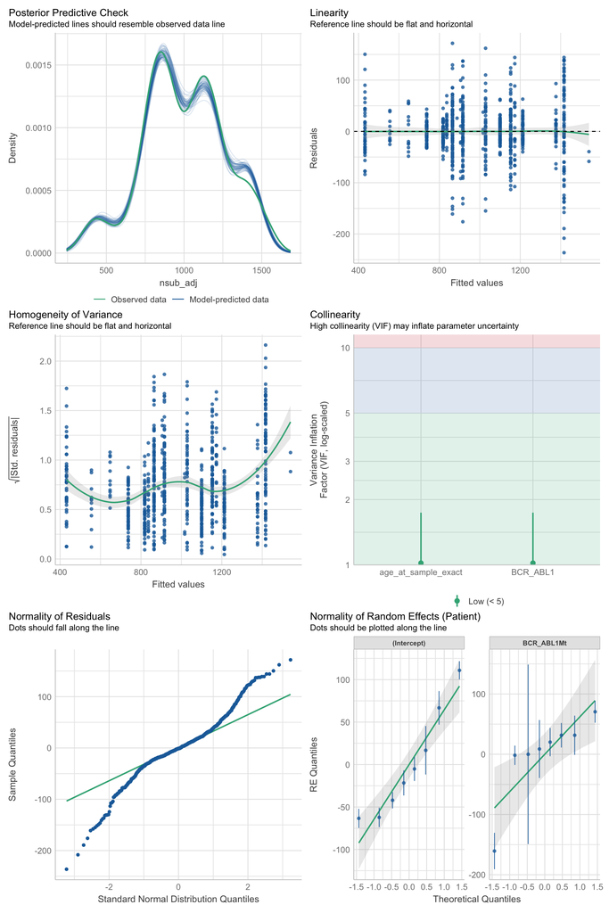

```r
check_model(SNV.lmer2_3.REML)
```

### Model summary

```r
tab_model(
  SNV.lmer2_3.REML,
  show.se = T,
  show.stat = T,
  show.ci = F,
  show.p = F,
  p.style = "scientific"
)
```

|  | SNV burden(depth adjusted) |  |  |
| --- | --- | --- | --- |
| Predictors | Estimates | std. Error | Statistic |
| (Intercept) | 36.45 | 56.16 | 0.65 |
| Age(years) | 18.13 | 0.98 | 18.47 |
| BCR::ABL 1 status: Mt | 91.72 | 29.58 | 3.10 |
| Random Effects |  |  |  |
| σ<sup>2</sup> | 2556.59 |  |  |
| τ<sub>00</sub> <sub>Patient</sub> | 4148.21 |  |  |
| τ<sub>11</sub> <sub>Patient.BCR_ABL1Mt</sub> | 5777.57 |  |  |
| ρ<sub>01</sub> <sub>Patient</sub> | 0.00 |  |  |
| ICC | 0.72 |  |  |
| N <sub>Patient</sub> | 8 |  |  |
| Observations | 799 |  |  |
| Marginal R<sup>2</sup> / Conditional R<sup>2</sup> | 0.829 / 0.952 |  |  |

### Bootstrapped fixed effects CIs

```r
set.seed(1234)

SNV.lmer2_3_par_boot <-
  bootstrap(
    SNV.lmer2_3.REML,
    .f = fixef,
    type = "parametric",
    B = 3000
  )
SNV.lmer2_3_par_boot
## Bootstrap type: parametric
##
## Number of resamples: 3000
##
##                  term observed rep.mean        se        bias
## 1         (Intercept) 36.44647 37.24291 60.479731  0.79643749
## 2 age_at_sample_exact 18.13239 18.12235  1.072425 -0.01004277
## 3          BCR_ABL1Mt 91.71826 91.39452 29.741173 -0.32373435
##
## There were 10 messages, 0 warnings, and 0 errors.
##
## The most commonly occurring message was: boundary (singular) fit: see help('isSingular')
```

#### Restricted to first 1000/3000 bootstrapped models

```r
SNV.lmer2_3_par_boot2 <- SNV.lmer2_3_par_boot
SNV.lmer2_3_par_boot2$replicates <- SNV.lmer2_3_par_boot$replicates[1:1000, ]
lmeresampler:::confint.lmeresamp(SNV.lmer2_3_par_boot2, type = "perc") %>% tab_df()
```

| term | estimate | lower | upper | type | level |
| --- | --- | --- | --- | --- | --- |
| (Intercept) | 36.45 | -77.73 | 152.83 | perc | 0.95 |
| age_at_sample_exact | 18.13 | 16.07 | 20.15 | perc | 0.95 |
| BCR_ABL1Mt | 91.72 | 30.58 | 150.39 | perc | 0.95 |

```r
keep.lgl.vec <- sapply(SNV.lmer2_3_par_boot$message, is.null) & sapply(SNV.lmer2_3_par_boot$warning, is.null) & sapply(SNV.lmer2_3_par_boot$error, is.null)
```

```r
SNV.lmer2_3_par_boot3 <- SNV.lmer2_3_par_boot
SNV.lmer2_3_par_boot3$replicates <- SNV.lmer2_3_par_boot$replicates[keep.lgl.vec, ][1:1000,]
lmeresampler:::confint.lmeresamp(SNV.lmer2_3_par_boot3, type = "perc") %>% tab_df()
```

| term | estimate | lower | upper | type | level |
| --- | --- | --- | --- | --- | --- |
| (Intercept) | 36.45 | -76.48 | 152.62 | perc | 0.95 |
| age_at_sample_exact | 18.13 | 16.09 | 20.19 | perc | 0.95 |
| BCR_ABL1Mt | 91.72 | 33.63 | 151.58 | perc | 0.95 |

#### Plot model

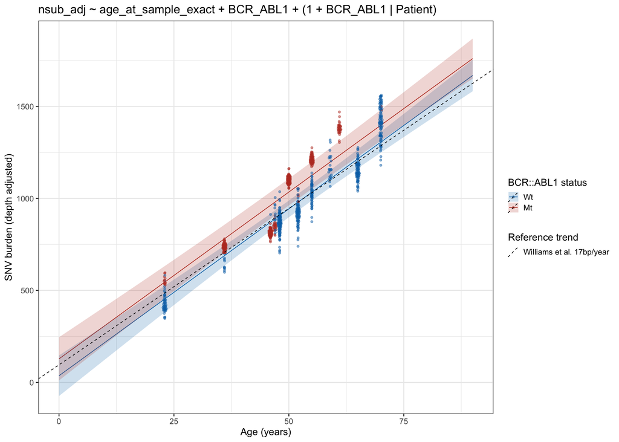

```r
d <-
  ggpredict(
    model = SNV.lmer2_3.REML,
    terms = c("age_at_sample_exact [0:90 by=5]", "BCR_ABL1"),
    ci.lvl = 0.95,
    type = "fe"
  )

d %>% as_tibble() %>%
  mutate(!!sym(get_legend_title(d)) := group) %>%
  ggplot(aes(
    x = x,
    y = predicted,
    group = !!sym(get_legend_title(d)),
  )) +
  geom_line(aes(colour = !!sym(get_legend_title(d)))) +
  geom_ribbon(aes(
    ymin = conf.low,
    ymax = conf.high,
    fill  = !!sym(get_legend_title(d))
  ), alpha = 0.2) +
  geom_quasirandom(
    data = attr(d, "rawdata") %>% mutate(!!sym(get_legend_title(d)) := group),
    aes(x = x, y = response, colour = group),
    alpha = 0.5
  ) +
  scale_colour_manual(name = "BCR::ABL1 status", values = driver.palette2) +
  scale_fill_manual(name = "BCR::ABL1 status", values = driver.palette2) +
  xlab(get_x_title(d)) +
  ylab(get_y_title(d)) +
  new_scale_fill() +
  geom_abline(
    data = as_tibble(list(
      a = c(95.6),
      b = c(17.0),
      `Reference trend` = c("Williams et al. 17bp/year")
    )),
    aes(
      intercept = a,
      slope = b,
      fill  = `Reference trend`
    ),
    lty = 2,
    show.legend = T
  )  +
  ggtitle(unlist(str_split(
    as.character(SNV.lmer2_3.REML@call), pattern = "\\="
  ))[2]) +
  theme_bw(base_size = 16)
```

### Figure 3a

Number of SNVs carried by sequenced colonies, coloured by driver status (*BCR::ABL1*, Other driver and wild-type) and their relationship with age, with mixed model trend lines. Red trend lines for colonies which are *BCR::ABL1*-positive and grey for *BCR::ABL1*-negative colonies.

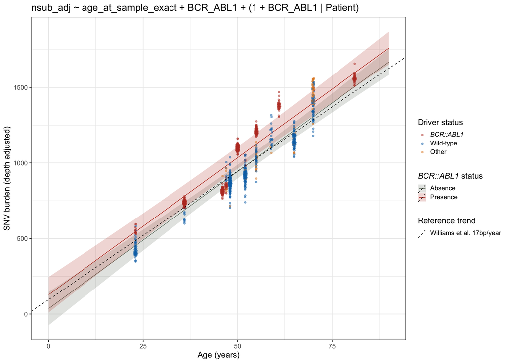

```r
Figure_3a_v2 <-
d %>% as_tibble() %>%
  mutate(group = case_when(group == "Wt" ~"Absence", group == "Mt" ~"Presence")) %>%
  mutate(`*BCR::ABL1* status` := group) %>%
  ggplot(aes(
    x = x,
    y = predicted,
    group = `*BCR::ABL1* status`,
  )) +
  geom_line(aes(colour = `*BCR::ABL1* status`)) +
  geom_ribbon(aes(
    ymin = conf.low,
    ymax = conf.high,
    fill  = `*BCR::ABL1* status`
  ), alpha = 0.2) +
  scale_colour_manual(name = "*BCR::ABL1* status", values = driver.palette2b) +
  scale_fill_manual(name = "*BCR::ABL1* status", values = driver.palette2b) +
  new_scale_fill() +
  new_scale_colour() +
  geom_quasirandom(
    data = plot3a.per_sample_statistics.n834.df %>%
    mutate(response = nsub_adj, x = age_at_sample_exact, group = driver2) %>% mutate(`Driver status` = factor(
      driver2,
      levels = c("BCR_ABL", "WT", "Other"),
      labels = c("*BCR::ABL1*", "Wild-type", "Other")
    )) %>% mutate(`*BCR::ABL1* status` := group),
    aes(x = x, y = response, colour = `Driver status`),
    alpha = 0.5
  ) +
  scale_colour_manual(values = driver.palette) +
  xlab(get_x_title(d)) +
  ylab(get_y_title(d)) +
  guides(colour = guide_legend(override.aes = list(linetype = c(rep(0, length(driver.palette)))))) +
  new_scale_fill() +
  geom_abline(
    data = as_tibble(list(
      a = c(95.6),
      b = c(17.0),
      `Reference trend` = c("Williams et al. 17bp/year")
    )),
    aes(
      intercept = a,
      slope = b,
      fill  = `Reference trend`
    ),
    lty = 2,
    show.legend = T
  )  +
  ggtitle(unlist(str_split(
    as.character(SNV.lmer2_3.REML@call), pattern = "\\="
  ))[2]) +
  theme_bw(base_size = 16) +
  theme(legend.title = element_markdown(), legend.text = element_markdown())
Figure_3a_v2
```

```r
ggsave(filename = paste0("../figures/v1/", "figure_3a_V1.pdf"), plot = Figure_3a_v2, width = 9, height = 5.625 )
```

### Figure 3f

Per sample dot plot for PD51635, describing mean C>T at CpG proportion (excluding *BCR::ABL1* clade trunk in *BCR::ABL1*-positive colonies) by sample *BCR::ABL1* fusion status, faceted by time of sampling and annotated by per sample driver status.

```r
PD51635.ctcpg_frq <-
  per_sample_statistics.n799.df %>%
  filter(Patient == "PD51635") %>%
  mutate(ctcpg_frq = case_when(BCR_ABL1 == "Mt" ~ ((nsub_ctcpg_adj - n_C_T_Trunk) / (nsub_adj - n_Trunk_total)
  ),
  TRUE ~ (nsub_ctcpg_adj / nsub_adj)))

PD51635.ctcpg_frq %>% mutate(age_at_sample_exact = as.character(age_at_sample_exact)) %>% count(age_at_sample_exact, BCR_ABL1) %>% addTotal() %>%  tab_df(col.header = c("Age at sample timepoint", "BCR::ABL1 fusion status", "n"))
```

| Age at sample timepoint | BCR::ABL1 fusion status | n |
| --- | --- | --- |
| 61 | Mt | 30 |
| 70 | Wt | 85 |
| 70 | Mt | 2 |
| Total | NA | 117 |

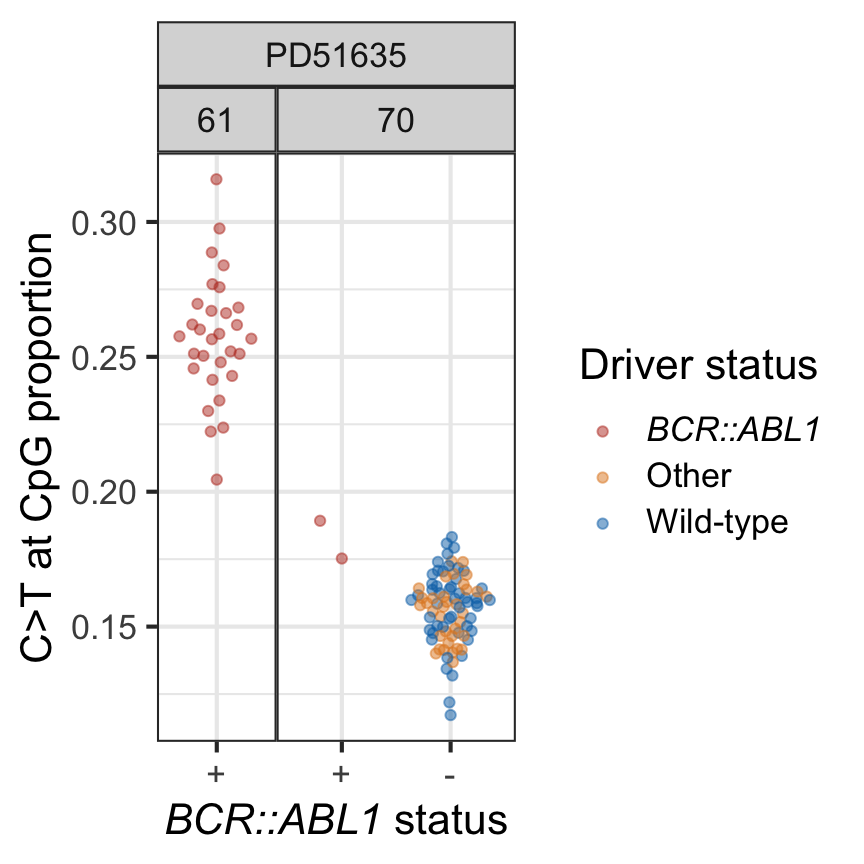

```r
Figure_3f.dat <-
  PD51635.ctcpg_frq %>%
  mutate(
    group = paste0(Patient, BCR_ABL1),
    # Age = as.character(age_at_sample_exact),
    Patient = factor(
      Patient,
      levels = c(
        "PD57334",
        "PD56961",
        "PD57335",
        "PD51634",
        "PD51633",
        "PD51632",
        "PD51635",
        "PD57333",
        "PD57332"
      )
    ),
    `*BCR::ABL1* status` = factor(
      BCR_ABL1,
      levels = c("Mt", "Wt"),
      labels = c("+", "-")
    ),
     `Driver status` = factor(
      driver2,
      levels = c("BCR_ABL", "Other", "WT"),
      labels = c("*BCR::ABL1*", "Other", "Wild-type")
    ),
    `C>T at CpG proportion` = ctcpg_frq,
    `Mutations SNV (adjusted)` = nsub_adj,
    `Age (years)` = age_at_sample_exact
  )

Figure_3f <-
Figure_3f.dat %>%
  ggplot(aes( `*BCR::ABL1* status`,
             `C>T at CpG proportion`,
             colour = `Driver status`,
             group.by = group,)) +
  geom_quasirandom(width = 0.4, alpha = 0.5) +
  scale_colour_manual(values = driver.palette) +
  theme_bw(base_size = 16) +
  theme(
    legend.title = element_markdown(),
    legend.text = element_markdown(),
    axis.title.x = element_markdown(),
  ) +
  facet_nested(~ Patient + `Age (years)`, scales = "free_x") +
  force_panelsizes(cols = c(1, 2)) + theme(panel.spacing = unit(0, "lines"))

Figure_3f
```

```r
ggsave(filename = paste0("../figures/v1/", "figure_3f_V1.pdf"), plot = Figure_3f, width = 4.5, height =4.5 )
```